# Stat Rethinking - Cap 2

# Capítulo 2 - Gráficos y Cálculos

Partiremos con un poco de gráficas (para soltar la mano) respecto a los cálculos de la sección 2.1.1. Counting possibilities

```r
library(tidyverse) # el preambulo con message = FALSE evita exceso de output al cargar tidyverse
d <- # construímos las opciones para sacar bolitas en un 'tibble'
  tibble(p1 = 0, # se llena automáticamente con respecto a los otros
         p2 = rep(1:0, times = c(1, 3)), # repito 1:0, 1 vez el 1, 3 el cero
         p3 = rep(1:0, times = c(2, 2)),
         p4 = rep(1:0, times = c(3, 1)),
         p5 = 1)
head(d) # ver la cabecera de los datos (si no son muchos se ven todos)
```

| p1 | p2 | p3 | p4 | p5 |
| --- | --- | --- | --- | --- |
| 0 | 1 | 1 | 1 | 1 |
| 0 | 0 | 1 | 1 | 1 |
| 0 | 0 | 0 | 1 | 1 |
| 0 | 0 | 0 | 0 | 1 |

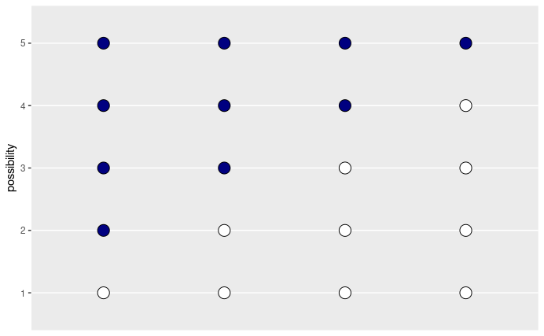

```r
d %>% # "pipe" (ie mando de un lado a otro)
  set_names(1:5) %>%
  mutate(x = 1:4) %>%
  pivot_longer(-x, names_to = "possibility") %>%
  mutate(value = value %>% as.character()) %>%

  ggplot(aes(x = x, y = possibility, fill = value)) +
  geom_point(shape = 21, size = 5) +
  scale_fill_manual(values = c("white", "navy")) +
  scale_x_discrete(NULL, breaks = NULL) +
  theme(legend.position = "none")
```

Ahora tabulemos los casos posibles de cada tirada:

```r
library(flextable)

tibble(draw    = 1:3,
       marbles = 4) %>%
  mutate(possibilities = marbles ^ draw) %>%
  flextable()
```

| draw | marbles | possibilities |
| --- | --- | --- |
| 1 | 4 | 4 |
| 2 | 4 | 16 |
| 3 | 4 | 64 |

```r
# y la estructura de datos de la fig 2.2 (las 64 config para una eleccion fija bwww)
(
  d <-
  tibble(position = c((1:4^1) / 4^0,
                      (1:4^2) / 4^1,
                      (1:4^3) / 4^2),
         draw     = rep(1:3, times = c(4^1, 4^2, 4^3)),
         fill     = rep(c("b", "w"), times = c(1, 3)) %>%
           rep(., times = c(4^0 + 4^1 + 4^2)))
) # los parentesis es para que tire output
```

| position | draw | fill |
| --- | --- | --- |
| 1.0000 | 1 | b |
| 2.0000 | 1 | w |
| 3.0000 | 1 | w |
| 4.0000 | 1 | w |
| 0.2500 | 2 | b |
| 0.5000 | 2 | w |
| 0.7500 | 2 | w |
| 1.0000 | 2 | w |
| 1.2500 | 2 | b |
| 1.5000 | 2 | w |

[output cut: 74 more lines]

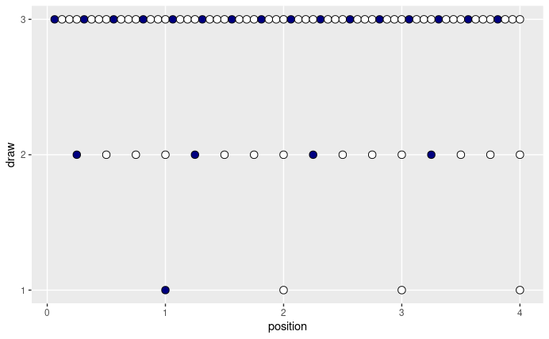

```r
d %>%
  ggplot(aes(x = position, y = draw, fill = fill)) +
  geom_point(shape = 21, size = 3) +
  scale_fill_manual(values  = c("navy", "white")) +
  scale_y_continuous(breaks = 1:3) +
  theme(legend.position = "none",
        panel.grid.minor = element_blank())
```

Para conectar los tibbles (líneas), se agrega un poco más de código

```r
# these will connect the dots from the first and second draws
(
  lines_1 <-
  tibble(x    = rep(1:4, each = 4),
         xend = ((1:4^2) / 4),
         y    = 1,
         yend = 2)
  )
```

| x | xend | y | yend |
| --- | --- | --- | --- |
| 1 | 0.25 | 1 | 2 |
| 1 | 0.50 | 1 | 2 |
| 1 | 0.75 | 1 | 2 |
| 1 | 1.00 | 1 | 2 |
| 2 | 1.25 | 1 | 2 |
| 2 | 1.50 | 1 | 2 |
| 2 | 1.75 | 1 | 2 |
| 2 | 2.00 | 1 | 2 |
| 3 | 2.25 | 1 | 2 |
| 3 | 2.50 | 1 | 2 |

[output cut: 6 more lines]

```r
# these will connect the dots from the second and third draws
(
  lines_2 <-
  tibble(x    = rep((1:4^2) / 4, each = 4),
         xend = (1:4^3) / (4^2),
         y    = 2,
         yend = 3)
  )
```

| x | xend | y | yend |
| --- | --- | --- | --- |
| 0.25 | 0.0625 | 2 | 3 |
| 0.25 | 0.1250 | 2 | 3 |
| 0.25 | 0.1875 | 2 | 3 |
| 0.25 | 0.2500 | 2 | 3 |
| 0.50 | 0.3125 | 2 | 3 |
| 0.50 | 0.3750 | 2 | 3 |
| 0.50 | 0.4375 | 2 | 3 |
| 0.50 | 0.5000 | 2 | 3 |
| 0.75 | 0.5625 | 2 | 3 |
| 0.75 | 0.6250 | 2 | 3 |

[output cut: 54 more lines]

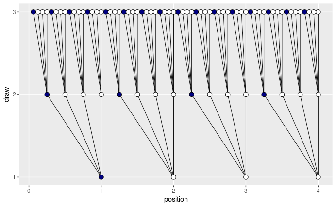

```r
d %>%
  ggplot(aes(x = position, y = draw)) +
  geom_segment(data = lines_1,
               aes(x = x, xend = xend,
                   y = y, yend = yend),
               linewidth = 1/3) +
  geom_segment(data = lines_2,
               aes(x = x, xend = xend,
                   y = y, yend = yend),
               linewidth = 1/3) +
  geom_point(aes(fill = fill),
             shape = 21, size = 3) +
  scale_fill_manual(values  = c("navy", "white")) +
  scale_y_continuous(breaks = 1:3) +
  theme(legend.position = "none",
        panel.grid.minor = element_blank())
```

Ahora para centrarlos, copio simplemente lo descrito: We’ve generated the values for position (i.e., the x-axis), in such a way that they’re all justified to the right, so to speak. But we’d like to center them. For draw == 1, we’ll need to subtract 0.5 from each. For draw == 2, we need to reduce the scale by a factor of 4 and we’ll then need to reduce the scale by another factor of 4 for draw == 3. The ifelse() function will be of use for that.

```r
d <-
  d %>%
  mutate(denominator = ifelse(draw == 1, .5,
                              ifelse(draw == 2, .5 / 4,
                                     .5 / 4^2))) %>%
  mutate(position = position - denominator)

d
```

| position | draw | fill | denominator |
| --- | --- | --- | --- |
| 0.50000 | 1 | b | 0.50000 |
| 1.50000 | 1 | w | 0.50000 |
| 2.50000 | 1 | w | 0.50000 |
| 3.50000 | 1 | w | 0.50000 |
| 0.12500 | 2 | b | 0.12500 |
| 0.37500 | 2 | w | 0.12500 |
| 0.62500 | 2 | w | 0.12500 |
| 0.87500 | 2 | w | 0.12500 |
| 1.12500 | 2 | b | 0.12500 |
| 1.37500 | 2 | w | 0.12500 |

[output cut: 74 more lines]

```r
(
  lines_1 <-
  lines_1 %>%
  mutate(x    = x - 0.5,
         xend = xend - 0.5 / 4^1)
)
```

| x | xend | y | yend |
| --- | --- | --- | --- |
| 0.5 | 0.125 | 1 | 2 |
| 0.5 | 0.375 | 1 | 2 |
| 0.5 | 0.625 | 1 | 2 |
| 0.5 | 0.875 | 1 | 2 |
| 1.5 | 1.125 | 1 | 2 |
| 1.5 | 1.375 | 1 | 2 |
| 1.5 | 1.625 | 1 | 2 |
| 1.5 | 1.875 | 1 | 2 |
| 2.5 | 2.125 | 1 | 2 |
| 2.5 | 2.375 | 1 | 2 |

[output cut: 6 more lines]

```r
(
  lines_2 <-
  lines_2 %>%
  mutate(x    = x - 0.5 / 4^1,
         xend = xend - 0.5 / 4^2)
)
```

| x | xend | y | yend |
| --- | --- | --- | --- |
| 0.125 | 0.03125 | 2 | 3 |
| 0.125 | 0.09375 | 2 | 3 |
| 0.125 | 0.15625 | 2 | 3 |
| 0.125 | 0.21875 | 2 | 3 |
| 0.375 | 0.28125 | 2 | 3 |
| 0.375 | 0.34375 | 2 | 3 |
| 0.375 | 0.40625 | 2 | 3 |
| 0.375 | 0.46875 | 2 | 3 |
| 0.625 | 0.53125 | 2 | 3 |
| 0.625 | 0.59375 | 2 | 3 |

[output cut: 54 more lines]

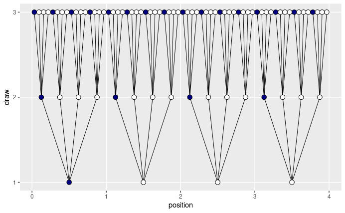

```r
d %>%
  ggplot(aes(x = position, y = draw)) +
  geom_segment(data = lines_1,
               aes(x = x, xend = xend,
                   y = y, yend = yend),
               linewidth = 1/3) +
  geom_segment(data = lines_2,
               aes(x = x, xend = xend,
                   y = y, yend = yend),
               linewidth = 1/3) +
  geom_point(aes(fill = fill),
             shape = 21, size = 3) +
  scale_fill_manual(values  = c("navy", "white")) +
  scale_y_continuous(breaks = 1:3) +
  theme(legend.position = "none",
        panel.grid.minor = element_blank())
```

Ahora se pasa a coordenadas polares

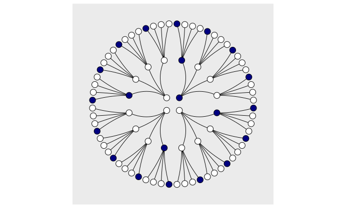

```r
d %>%
  ggplot(aes(x = position, y = draw)) +
  geom_segment(data = lines_1,
               aes(x = x, xend = xend,
                   y = y, yend = yend),
               linewidth = 1/3) +
  geom_segment(data = lines_2,
               aes(x = x, xend = xend,
                   y = y, yend = yend),
               linewidth = 1/3) +
  geom_point(aes(fill = fill),
             shape = 21, size = 4) +
  scale_fill_manual(values = c("navy", "white")) +
  scale_x_continuous(NULL, limits = c(0, 4), breaks = NULL) +
  scale_y_continuous(NULL, limits = c(0.75, 3), breaks = NULL) +
  coord_polar() +
  theme(legend.position = "none",
        panel.grid = element_blank())
```

Ahora para ensombrecer, se agrega un índice para declarar cuales caminos son válidos

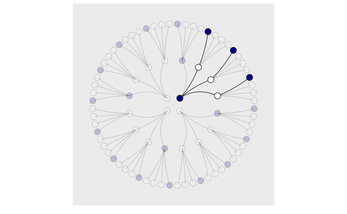

```r
lines_1 <-
  lines_1 %>%
  mutate(remain = c(rep(0:1, times = c(1, 3)),
                    rep(0,   times = 4 * 3)))
lines_2 <-
  lines_2 %>%
  mutate(remain = c(rep(0,   times = 4),
                    rep(1:0, times = c(1, 3)) %>% rep(., times = 3),
                    rep(0,   times = 12 * 4)))
d <-
  d %>%
  mutate(remain = c(rep(1:0, times = c(1, 3)),
                    rep(0:1, times = c(1, 3)),
                    rep(0,   times = 4 * 4),
                    rep(1:0, times = c(1, 3)) %>% rep(., times = 3),
                    rep(0,   times = 12 * 4)))
# finally, the plot:
d %>%
  ggplot(aes(x = position, y = draw)) +
  geom_segment(data = lines_1,
               aes(x = x, xend = xend,
                   y = y, yend = yend,
                   alpha = remain %>% as.character()),
               linewidth = 1/3) +
  geom_segment(data = lines_2,
               aes(x = x, xend = xend,
                   y = y, yend = yend,
                   alpha = remain %>% as.character()),
               linewidth = 1/3) +
  geom_point(aes(fill = fill, alpha = remain %>% as.character()),
             shape = 21, size = 4) +
  # it's the alpha parameter that makes elements semitransparent
  scale_fill_manual(values = c("navy", "white")) +
  scale_alpha_manual(values = c(1/5, 1)) +
  scale_x_continuous(NULL, limits = c(0, 4), breaks = NULL) +
  scale_y_continuous(NULL, limits = c(0.75, 3), breaks = NULL) +
  coord_polar() +
  theme(legend.position = "none",
        panel.grid = element_blank())
```

Construcción tabla pag 23

```r
# if we make two custom functions, here,
# it will simplify the `mutate()` code, below
n_blue  <- function(x) rowSums(x == "b")
n_white <- function(x) rowSums(x == "w")

# make the data
t <-
  tibble(d1 = rep(c("w", "b"), times = c(1, 4)),
         d2 = rep(c("w", "b"), times = c(2, 3)),
         d3 = rep(c("w", "b"), times = c(3, 2)),
         d4 = rep(c("w", "b"), times = c(4, 1))) %>%
  mutate(blue1 = n_blue(.),
         white = n_white(.),
         blue2 = n_blue(.)) %>%
  mutate(product = blue1 * white * blue2)

# format the table
t %>%
  transmute(conjecture = str_c("[", d1, " ", d2, " ", d3, " ", d4, "]"),
            `Ways to produce [w b w]` = str_c(blue1, " * ", white, " * ", blue2, " = ", product)) %>%
  flextable() %>%
  width(j = 1:2, width = c(1, 2)) %>%
  align(align = "center", part = "all")
```

| conjecture | Ways to produce [w b w] |
| --- | --- |
| [w w w w] | 0 * 4 * 0 = 0 |
| [b w w w] | 1 * 3 * 1 = 3 |
| [b b w w] | 2 * 2 * 2 = 8 |
| [b b b w] | 3 * 1 * 3 = 9 |
| [b b b b] | 4 * 0 * 4 = 0 |

Construcción figura 2.4, hay que agregar datos

```r
d <-
  tibble(position = c((1:4^1) / 4^0,
                      (1:4^2) / 4^1,
                      (1:4^3) / 4^2),
         draw     = rep(1:3, times = c(4^1, 4^2, 4^3)))

(
  d <-
  d %>%
  bind_rows(
    d, d
  ) %>%
  # here are the fill colors
  mutate(fill = c(rep(c("w", "b"), times = c(1, 3)) %>% rep(., times = c(4^0 + 4^1 + 4^2)),
                  rep(c("w", "b"), each  = 2)       %>% rep(., times = c(4^0 + 4^1 + 4^2)),
                  rep(c("w", "b"), times = c(3, 1)) %>% rep(., times = c(4^0 + 4^1 + 4^2)))) %>%
  # now we need to shift the positions over in accordance with draw, like before
  mutate(denominator = ifelse(draw == 1, .5,
                              ifelse(draw == 2, .5 / 4,
                                     .5 / 4^2))) %>%
  mutate(position = position - denominator) %>%
  # here we'll add an index for which pie wedge we're working with
  mutate(pie_index = rep(letters[1:3], each = n()/3)) %>%
  # to get the position axis correct for pie_index == "b" or "c", we'll need to offset
  mutate(position = ifelse(pie_index == "a", position,
                           ifelse(pie_index == "b", position + 4,
                                  position + 4 * 2)))
)
```

| position | draw | fill | denominator | pie_index |
| --- | --- | --- | --- | --- |
| 0.50000 | 1 | w | 0.50000 | a |
| 1.50000 | 1 | b | 0.50000 | a |
| 2.50000 | 1 | b | 0.50000 | a |
| 3.50000 | 1 | b | 0.50000 | a |
| 0.12500 | 2 | w | 0.12500 | a |
| 0.37500 | 2 | b | 0.12500 | a |
| 0.62500 | 2 | b | 0.12500 | a |
| 0.87500 | 2 | b | 0.12500 | a |
| 1.12500 | 2 | w | 0.12500 | a |
| 1.37500 | 2 | b | 0.12500 | a |

[output cut: 242 more lines]

```r
# funcion auxiliar
move_over <- function(position, index) {
  ifelse(
    index == "a", position,
    ifelse(
      index == "b", position + 4, position + 4 * 2
    )
  )
}
# uso de la funcion
(
  lines_1 <-
  tibble(x    = rep(1:4, each = 4) %>% rep(., times = 3),
         xend = ((1:4^2) / 4)      %>% rep(., times = 3),
         y    = 1,
         yend = 2) %>%
  mutate(x    = x - .5,
         xend = xend - .5 / 4^1) %>%
  # here we'll add an index for which pie wedge we're working with
  mutate(pie_index = rep(letters[1:3], each = n()/3)) %>%
  # to get the position axis correct for `pie_index == "b"` or `"c"`, we'll need to offset
  mutate(x    = move_over(position = x,    index = pie_index),
         xend = move_over(position = xend, index = pie_index))
)
```

| x | xend | y | yend | pie_index |
| --- | --- | --- | --- | --- |
| 0.5 | 0.125 | 1 | 2 | a |
| 0.5 | 0.375 | 1 | 2 | a |
| 0.5 | 0.625 | 1 | 2 | a |
| 0.5 | 0.875 | 1 | 2 | a |
| 1.5 | 1.125 | 1 | 2 | a |
| 1.5 | 1.375 | 1 | 2 | a |
| 1.5 | 1.625 | 1 | 2 | a |
| 1.5 | 1.875 | 1 | 2 | a |
| 2.5 | 2.125 | 1 | 2 | a |
| 2.5 | 2.375 | 1 | 2 | a |

[output cut: 38 more lines]

```r
(
  lines_2 <-
  tibble(x    = rep((1:4^2) / 4, each = 4) %>% rep(., times = 3),
         xend = (1:4^3 / 4^2)              %>% rep(., times = 3),
         y    = 2,
         yend = 3) %>%
  mutate(x    = x - .5 / 4^1,
         xend = xend - .5 / 4^2) %>%
  # here we'll add an index for which pie wedge we're working with
  mutate(pie_index = rep(letters[1:3], each = n()/3)) %>%
  # to get the position axis correct for `pie_index == "b"` or `"c"`, we'll need to offset
  mutate(x    = move_over(position = x,    index = pie_index),
         xend = move_over(position = xend, index = pie_index))
)
```

| x | xend | y | yend | pie_index |
| --- | --- | --- | --- | --- |
| 0.125 | 0.03125 | 2 | 3 | a |
| 0.125 | 0.09375 | 2 | 3 | a |
| 0.125 | 0.15625 | 2 | 3 | a |
| 0.125 | 0.21875 | 2 | 3 | a |
| 0.375 | 0.28125 | 2 | 3 | a |
| 0.375 | 0.34375 | 2 | 3 | a |
| 0.375 | 0.40625 | 2 | 3 | a |
| 0.375 | 0.46875 | 2 | 3 | a |
| 0.625 | 0.53125 | 2 | 3 | a |
| 0.625 | 0.59375 | 2 | 3 | a |

[output cut: 182 more lines]

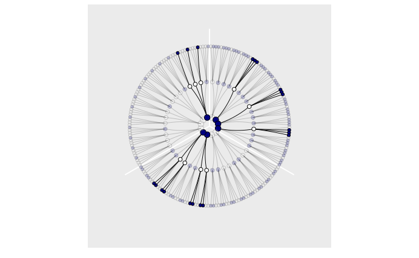

```r
# definir caminos validos
d <-
  d %>%
  mutate(remain = c(# pie_index == "a"
                    rep(0:1, times = c(1, 3)),
                    rep(0,   times = 4),
                    rep(1:0, times = c(1, 3)) %>% rep(., times = 3),
                    rep(0,   times = 4 * 4),
                    rep(c(0, 1, 0), times = c(1, 3, 4 * 3)) %>% rep(., times = 3),
                    # pie_index == "b"
                    rep(0:1, each = 2),
                    rep(0,   times = 4 * 2),
                    rep(1:0, each = 2) %>% rep(., times = 2),
                    rep(0,   times = 4 * 4 * 2),
                    rep(c(0, 1, 0, 1, 0), times = c(2, 2, 2, 2, 8)) %>% rep(., times = 2),
                    # pie_index == "c",
                    rep(0:1, times = c(3, 1)),
                    rep(0,   times = 4 * 3),
                    rep(1:0, times = c(3, 1)),
                    rep(0,   times = 4 * 4 * 3),
                    rep(0:1, times = c(3, 1)) %>% rep(., times = 3),
                    rep(0,   times = 4)
                    )
         )

lines_1 <-
  lines_1 %>%
  mutate(remain = c(rep(0,   times = 4),
                    rep(1:0, times = c(1, 3)) %>% rep(., times = 3),
                    rep(0,   times = 4 * 2),
                    rep(1:0, each  = 2) %>% rep(., times = 2),
                    rep(0,   times = 4 * 3),
                    rep(1:0, times = c(3, 1))
                    )
         )

lines_2 <-
  lines_2 %>%
  mutate(remain = c(rep(0,   times = 4 * 4),
                    rep(c(0, 1, 0), times = c(1, 3, 4 * 3)) %>% rep(., times = 3),
                    rep(0,   times = 4 * 8),
                    rep(c(0, 1, 0, 1, 0), times = c(2, 2, 2, 2, 8)) %>% rep(., times = 2),
                    rep(0,   times = 4 * 4 * 3),
                    rep(0:1, times = c(3, 1)) %>% rep(., times = 3),
                    rep(0,   times = 4)
                    )
         )
# voila
d %>%
  ggplot(aes(x = position, y = draw)) +
  geom_vline(xintercept = c(0, 4, 8), color = "white", linewidth = 2/3) +
  geom_segment(data = lines_1,
               aes(x = x, xend = xend,
                   y = y, yend = yend,
                   alpha = remain %>% as.character()),
               linewidth = 1/3) +
  geom_segment(data = lines_2,
               aes(x = x, xend = xend,
                   y = y, yend = yend,
                   alpha = remain %>% as.character()),
               linewidth = 1/3) +
  geom_point(aes(fill = fill, size = draw, alpha = remain %>% as.character()),
             shape = 21) +
  scale_fill_manual(values = c("navy", "white")) +
  scale_size_continuous(range = c(3, 1.5)) +
  scale_alpha_manual(values = c(0.2, 1)) +
  scale_x_continuous(NULL, limits = c(0, 12), breaks = NULL) +
  scale_y_continuous(NULL, limits = c(0.75, 3.5), breaks = NULL) +
  coord_polar() +
  theme(legend.position = "none",
        panel.grid = element_blank())
```

### Sec 2.1.2 Combinando otra info

Primero introduzcamos la tabla para el nuevo conteo

```r
# update t
t <-
  t %>%
  mutate(nc = blue1 * product)

# format the table
t %>%
  transmute(Conjecture            = str_c("[", d1, " ", d2, " ", d3, " ", d4, "]"),
            `Ways to produce [b]` = blue1,
            `Prior counts`        = product,
            `New count`           = str_c(blue1, " * ", product, " = ", nc)) %>%
  flextable() %>%
  width(width = c(1, 1, 0.8, 1)) %>%
  align(align = "center", part = "all") %>%
  align(j = 4, align = "left", part = "all") %>%
  valign(valign = "bottom", part = "header")
```

| Conjecture | Ways to produce [b] | Prior counts | New count |
| --- | --- | --- | --- |
| [w w w w] | 0 | 0 | 0 * 0 = 0 |
| [b w w w] | 1 | 3 | 1 * 3 = 3 |
| [b b w w] | 2 | 8 | 2 * 8 = 16 |
| [b b b w] | 3 | 9 | 3 * 9 = 27 |
| [b b b b] | 4 | 0 | 4 * 0 = 0 |

Update con los nuevos datos (fabrica)

```r
# update t
t <-
  t %>%
  rename(pc = nc) %>%
  mutate(fc = c(0, 3:0)) %>%
  mutate(nc = pc * fc)

# format the table
t %>%
  transmute(Conjecture      = str_c("[", d1, " ", d2, " ", d3, " ", d4, "]"),
            `Prior count`   = pc,
            `Factory count` = fc,
            `New count`     = str_c(pc, " * ", fc, " = ", nc)) %>%
  flextable() %>%
  width(width = c(1, 1, 0.8, 1)) %>%
  align(align = "center", part = "all") %>%
  align(j = 4, align = "left", part = "all") %>%
  valign(valign = "bottom", part = "header")
```

| Conjecture | Prior count | Factory count | New count |
| --- | --- | --- | --- |
| [w w w w] | 0 | 0 | 0 * 0 = 0 |
| [b w w w] | 3 | 3 | 3 * 3 = 9 |
| [b b w w] | 16 | 2 | 16 * 2 = 32 |
| [b b b w] | 27 | 1 | 27 * 1 = 27 |
| [b b b b] | 0 | 0 | 0 * 0 = 0 |

```r
NA
```

Y finalmente (para esta parte) introduciendo el concepto de Plausabilidad y su tabla respectiva

```r
# update t
t %>%
  rename(ways = product) %>%
  mutate(p = blue1 / 4) %>%
  mutate(pl = ways / sum(ways)) %>%
  transmute(`Possible composition` = str_c("[", d1, " ", d2, " ", d3, " ", d4, "]"),
            p                      = p,
            `Ways to produce data` = ways,
            `Plausibility`         = pl) %>%

  # format for the table
  flextable() %>%
  width(width = c(1.8, 1, 1.2, 1)) %>%
  align(align = "center", part = "all") %>%
  valign(valign = "bottom", part = "header") %>%
  italic(j = 2, part = "header")
```

| Possible composition | p | Ways to produce data | Plausibility |
| --- | --- | --- | --- |
| [w w w w] | 0.00 | 0 | 0.00 |
| [b w w w] | 0.25 | 3 | 0.15 |
| [b b w w] | 0.50 | 8 | 0.40 |
| [b b b w] | 0.75 | 9 | 0.45 |
| [b b b b] | 1.00 | 0 | 0.00 |

el autor muestra que el cálculo fue:

```r
ways <- c(0, 3, 8, 9, 0)

ways / sum(ways)
```

```
[1] 0.00 0.15 0.40 0.45 0.00
```